# Mash Model Tuning

`r`r library(tidyverse) library(mashr) library(corrplot)

## Estimating correlation

First, we compare three methods for estimating correlation structure

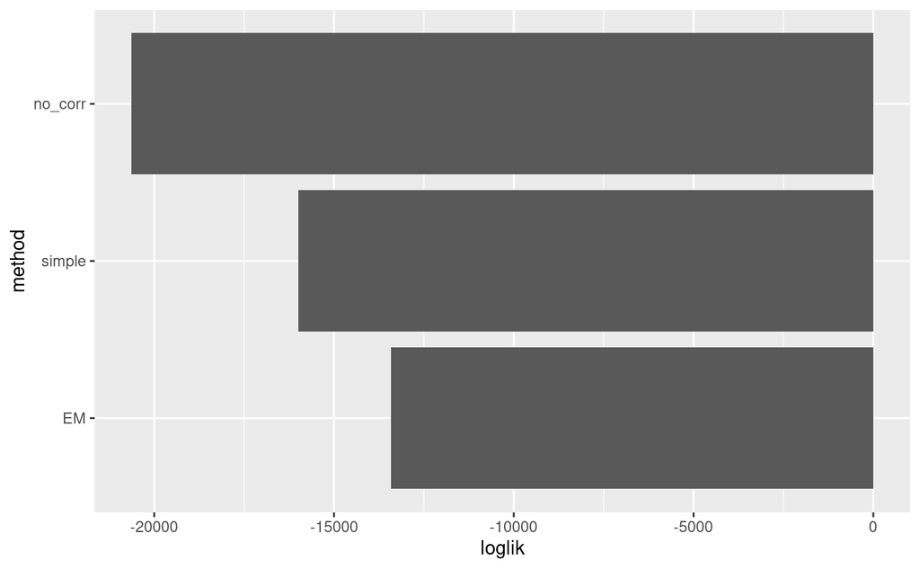

We can see that the EM procedure offers the highest log likelihood, so we'll move forward with that.

## Comparing correlation

When directly comparing the correlation matrices learned by these two approaches we see that they follow a similar pattern but the EM approach offers higher magnitude correlations

`r`r corrplot(V.simple, pch.cex=0.1, tl.pos='l')

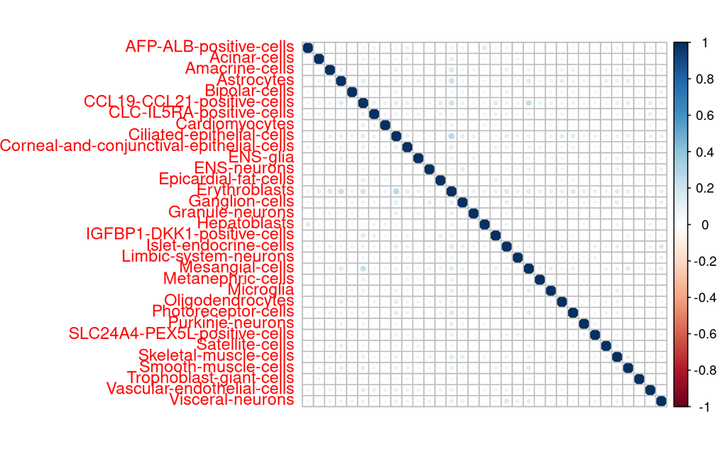

`r`r corrplot(V.em, pch.cex=0.1, tl.pos='l')

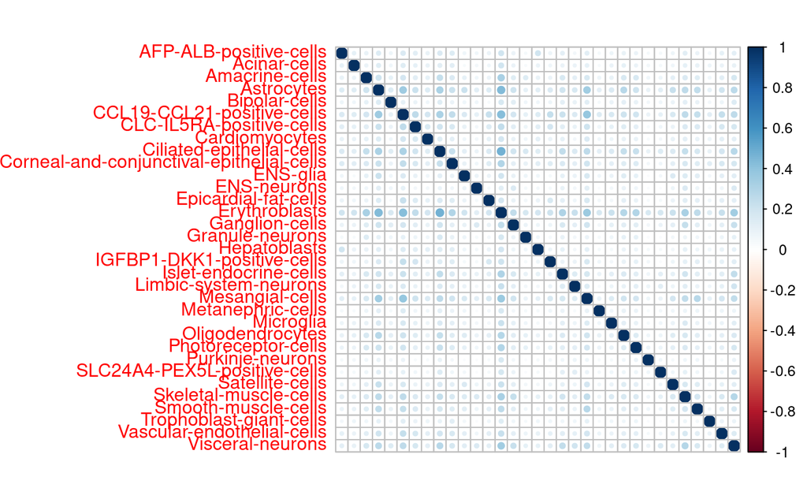

It looks like the two matrices are highly correlated but the simple approach just underestimates the magnitudes

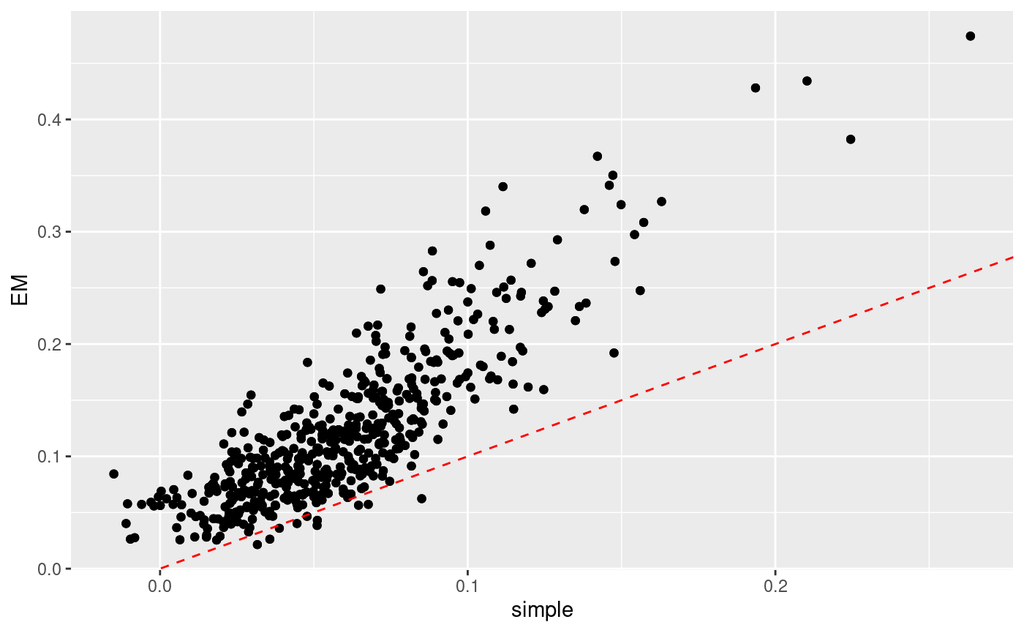

## Tuning alpha

```
Delimiter: \\t\
```

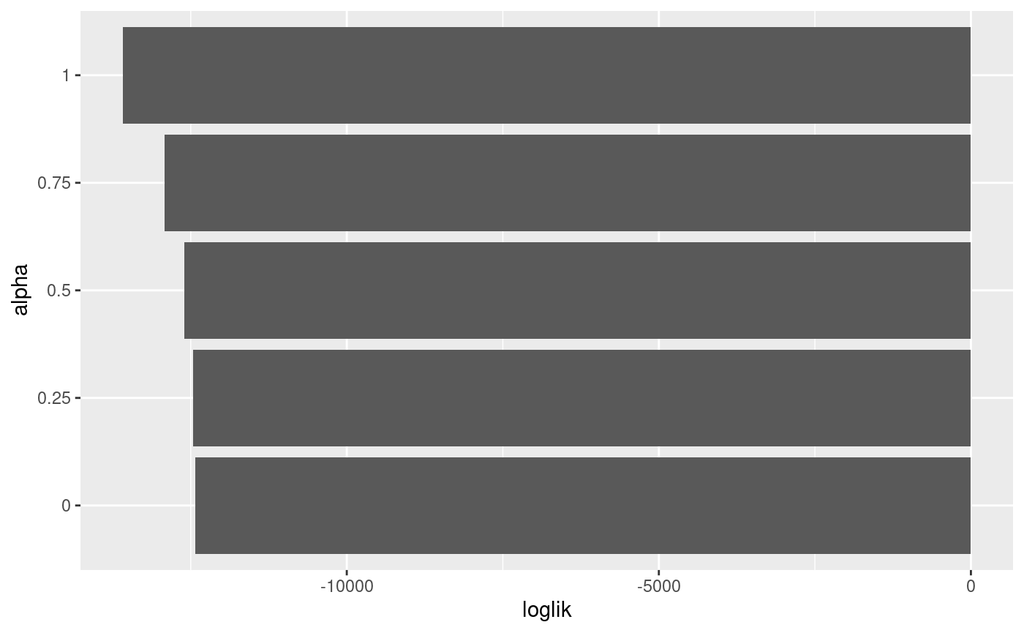

Looks like choice of alpha doesn't make a huge difference but the EE model works best (alpha=0, largest log likelihood).

## Data-Driven Covariance Matrices

```r
load("/project2/gilad/jpopp/ebQTL/results/static/highpass_cellid_all/pseudobulk-scran/basic/mashr_U_eval.RData")
```

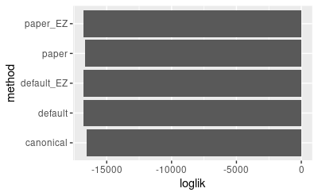

```r
U_eval <- tibble("method"=c("canonical", "default", "default_EZ",
                  "paper", "paper_EZ"),
       "loglik"=c(get_loglik(m.simple.test),
                  get_loglik(m.default.test),
                  get_loglik(m.default.test.EZ),
                  get_loglik(m.paper.test),
                  get_loglik(m.paper.test.EZ)))
U_eval %>%
  mutate(method=factor(method, levels=c("canonical", "default", "default_EZ", "paper", "paper_EZ"))) %>%
  ggplot(aes(x=method, y=loglik)) +
  geom_bar(stat="identity") +
  coord_flip()
```